# Models for COVID Deaths

Harry Giles

# Background

Here is some justification for modelling log(deaths) as quadratic in time $t$. [Needs more work.]

Let $I(t)$ be the number of infected people at time $t$ in a population of fixed size $P$. Suppose when you get infected you stay infectious, and each person transmits the disease to the same number of (potentially already infected) people each day. Then $I(t)$ is goverened by the following equation:
$$I'(t) \propto I(t)(P-I(t))$$
The solution is some rescaling of the the logistic funcion, $\tfrac{1}{1+e^{-t}}$.

Well, the error function looks a lot like the logistic function, and if we model $I(t)$ as a rescaling of the error function, then the daily infection rate $I'(t)$ satisfies
$$\log(I'(t)) \propto -k(t-t_0)^2$$
This looks a lot like Poisson regression with quadratic terms.

Finally, It seems reasonable to model the number of deaths as proportional to $I(t - t_\text{lag})$.

# Italy

To begin we will use the first 25 days of data starting from when the country first had 10 deaths.

## Model selection (Poisson)

We fit a poisson model, and see that quadratic features are justified.

```r
model.1 <-
  glm(deaths ~ t + I(t^2),
      family = poisson,
      data = italy.df)
anova(model.1, test = "Chisq")
```

```
## Analysis of Deviance Table
##
## Model: poisson, link: log
##
## Response: deaths
##
## Terms added sequentially (first to last)
##
##
##        Df Deviance Resid. Df Resid. Dev  Pr(>Chi)
## NULL                      24     5501.6
## t       1   4868.1        23      633.5 < 2.2e-16 ***
## I(t^2)  1    416.0        22      217.5 < 2.2e-16 ***
## ---
## Signif. codes:  0 '***' 0.001 '**' 0.01 '*' 0.05 '.' 0.1 ' ' 1
```

```r
summary(model.1)
```

```
##
## Call:
## glm(formula = deaths ~ t + I(t^2), family = poisson, data = italy.df)
##
## Deviance Residuals:
##    Min      1Q  Median      3Q     Max
## -6.849  -1.297   0.042   1.928   7.396
##
## Coefficients:
##               Estimate Std. Error z value Pr(>|z|)
## (Intercept) -4.161e+01  2.032e+00  -20.48   <2e-16 ***
## t            1.121e+00  5.275e-02   21.25   <2e-16 ***
## I(t^2)      -6.521e-03  3.411e-04  -19.12   <2e-16 ***
## ---
## Signif. codes:  0 '***' 0.001 '**' 0.01 '*' 0.05 '.' 0.1 ' ' 1
##
## (Dispersion parameter for poisson family taken to be 1)
##
##     Null deviance: 5501.62  on 24  degrees of freedom
## Residual deviance:  217.51  on 22  degrees of freedom
## AIC: 401.41
##
## Number of Fisher Scoring iterations: 4
```

## Plots and dispersion

We plot the fitted values on a linear and log scale. In the log plot we include a prediction interval, being two stdevs of parameter error, plus two stdevs of poisson variation.

The plots suggest overdispersion (a Poisson glm has a dispersion of 1). The dispersion estimate $\hat{\phi}$ for this model is 9.8304279, which under the model is asymptotically distributed as $\frac{1}{(n-p)}\chi^2_{n-p}$. We have extreme over-dispersion, which means that we should not take seriously confidence intervals for the parameters or expected response. Let’s fix that in the next section.

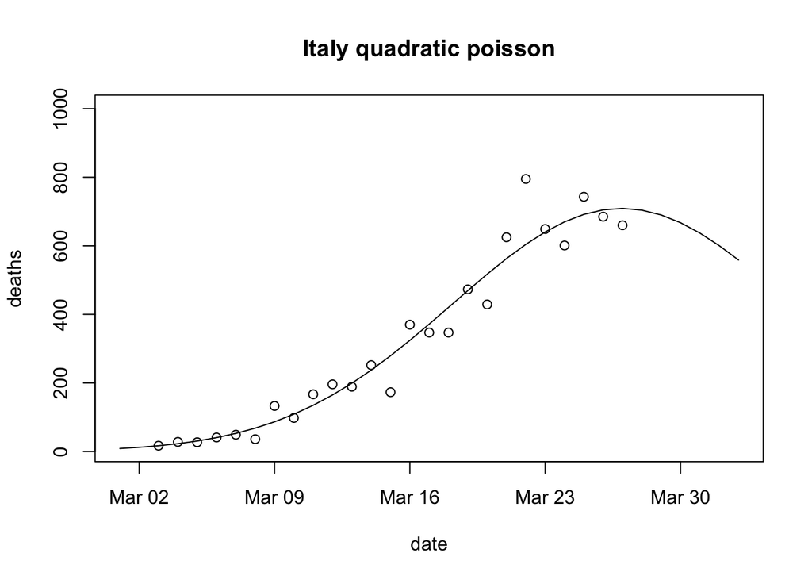

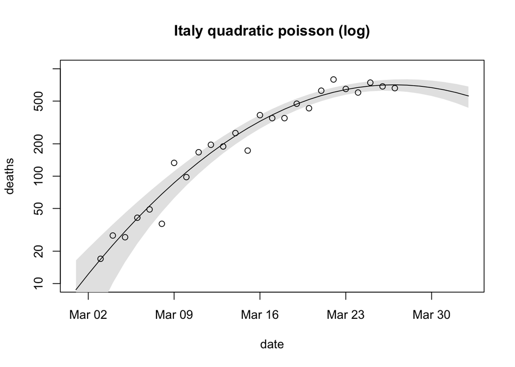

```r
plot(
  newdata$dateRep,
  newdata$deaths,
  main = "Italy quadratic poisson",
  xlab = "date",
  ylab = "deaths",
  type = "l",
  ylim = c(10, 1000)
)
points(italy.df$dateRep, italy.df$deaths)
```

## Quasi-poisson model

```r
model.2 <-
  glm(deaths ~ t + I(t^2),
      family = quasipoisson,
      data = italy.df)
summary(model.2)
```

```
##
## Call:
## glm(formula = deaths ~ t + I(t^2), family = quasipoisson, data = italy.df)
##
## Deviance Residuals:
##    Min      1Q  Median      3Q     Max
## -6.849  -1.297   0.042   1.928   7.396
##
## Coefficients:
##               Estimate Std. Error t value Pr(>|t|)
## (Intercept) -41.609709   6.371410  -6.531 1.44e-06 ***
## t             1.120942   0.165376   6.778 8.23e-07 ***
## I(t^2)       -0.006521   0.001069  -6.097 3.89e-06 ***
## ---
## Signif. codes:  0 '***' 0.001 '**' 0.01 '*' 0.05 '.' 0.1 ' ' 1
##
## (Dispersion parameter for quasipoisson family taken to be 9.830428)
##
##     Null deviance: 5501.62  on 24  degrees of freedom
## Residual deviance:  217.51  on 22  degrees of freedom
## AIC: NA
##
## Number of Fisher Scoring iterations: 4
```

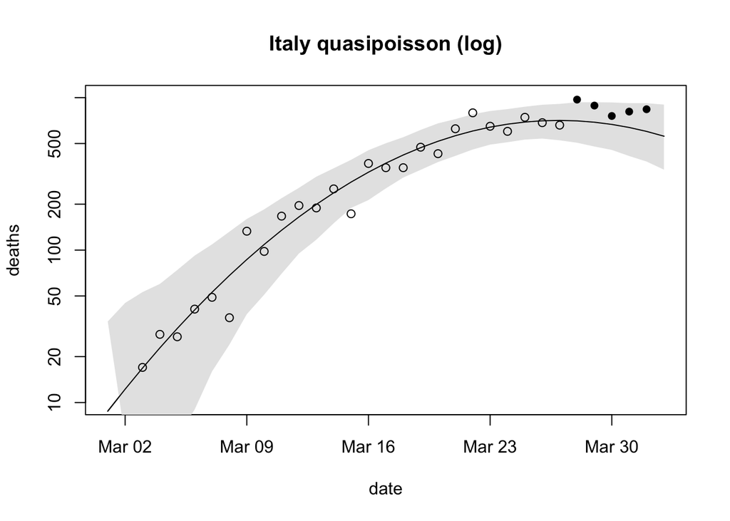

# TODO

- Look at other countries, potentailly try to squeeze the models together
- Try to address the non-stationarity of the distribution, e.g. we could add a predictor for which control measures were in place on a given day
- A simpler suggestion: we could put more weight on more recent datapoints